# PA1_template

## Loading the data

First we load the data and required packages.

```r
require(plyr)
```

```r
require(ggplot2)
rawdata<-read.csv("activity.csv")
head(rawdata)
```

```
##   steps       date interval
## 1    NA 2012-10-01        0
## 2    NA 2012-10-01        5
## 3    NA 2012-10-01       10
## 4    NA 2012-10-01       15
## 5    NA 2012-10-01       20
## 6    NA 2012-10-01       25
```

## What is mean total number of steps taken per day?

### Make a histogram of the total number of steps taken each day

```r
processed<-ddply(rawdata,.(date),summarize,steps=sum(steps,na.rm=TRUE))
head(processed)
```

```
##         date steps
## 1 2012-10-01     0
## 2 2012-10-02   126
## 3 2012-10-03 11352
## 4 2012-10-04 12116
## 5 2012-10-05 13294
## 6 2012-10-06 15420
```

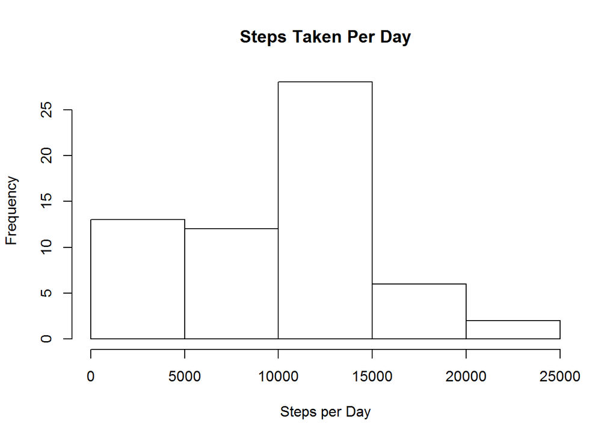

```r
hist(processed$steps,xlab="Steps per Day", main=paste("Steps Taken Per Day"))
```

```r
meansteps<- mean(processed$steps,na.rm= TRUE)
mediansteps<-median(processed$steps,na.rm= TRUE)
```

## What is the average daily activity pattern?

### Make a time series plot (i.e. type = “l”) of the 5-minute interval (x-axis) and the average number of steps taken, averaged across all days (y-axis)

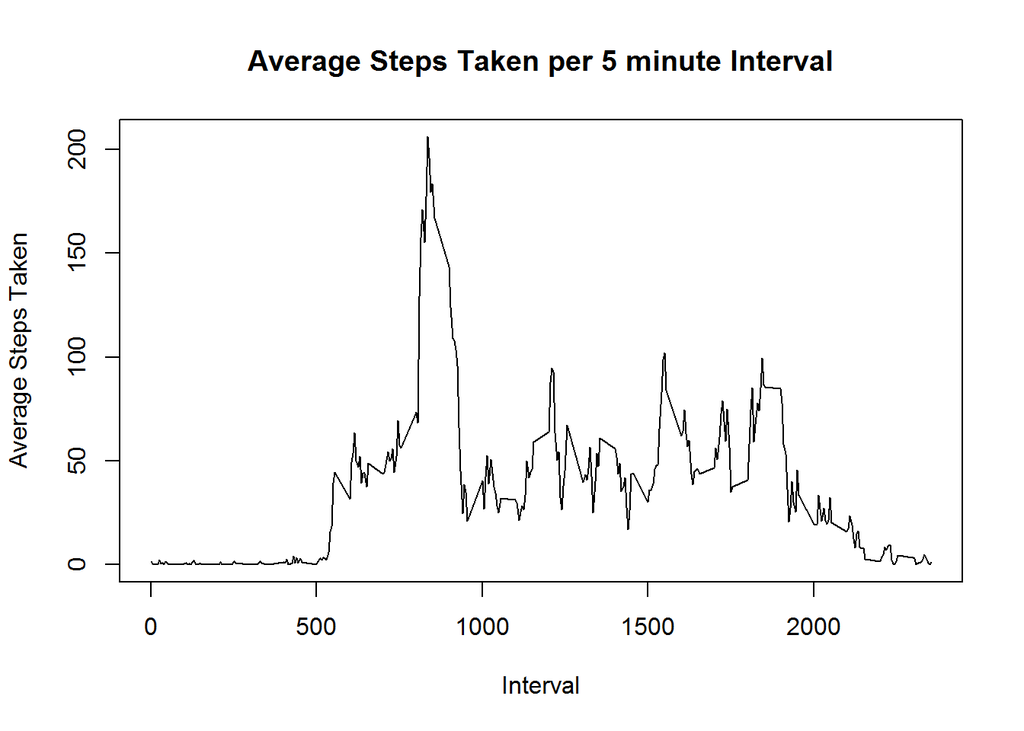

```r
processedts<-ddply(rawdata,.(interval),summarise,steps=mean(steps,na.rm=TRUE))
plot(processedts$interval, processedts$steps, type="l", xlab="Interval",ylab="Average Steps Taken", main="Average Steps Taken per 5 minute Interval")
```

```r
maxinterval <-processedts$interval[which.max(processedts$steps)]
```

### Which 5-minute interval, on average across all the days in the dataset, contains the maximum number of steps?

The interval with the most steps taken on average is 835

## Imputing Missing Values

### Calculate and report the total number of missing values in the dataset (i.e. the total number of rows with NAs)

```r
numna<- sum(is.na(rawdata$steps))
```

Number of missing values = 2304

### Devise a strategy for filling in all of the missing values in the dataset. + Create a new dataset that is equal to the original dataset but with the missing data filled in.

Using mean for the 5-minute interval to impute NAs  
1. Pull out rows with NA  
2. Join using previous dataset  
3. Add it back to the original data set while removing NA rows

```r
moddata<-rawdata[is.na(rawdata$steps),]
moddata[,1]=NULL
moddata<-join(moddata, processedts, by="interval",type="left")
moddata<-rbind(rawdata,moddata)
moddata<-na.omit(moddata)
```

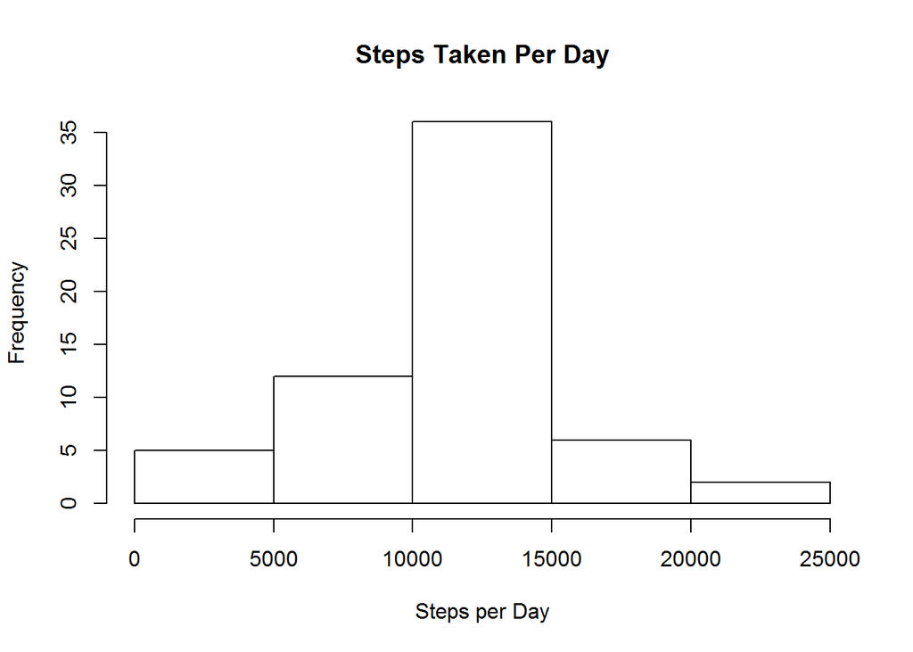

```r
processedmod<-ddply(moddata,.(date),summarize,steps=sum(steps,na.rm=TRUE))
hist(processedmod$steps,xlab="Steps per Day", main=paste("Steps Taken Per Day"))
```

```r
meanstepsmod<- mean(processedmod$steps)
medianstepsmod<-median(processedmod$steps)
```

## Are there differences in activity patterns between weekdays and weekends?

### Create a new factor variable in the dataset with two levels – “weekday” and “weekend” indicating whether a given date is a weekday or weekend day.

```r
rawdata$day<-weekdays(as.Date(rawdata$date))
weekdays1 <- c('Monday', 'Tuesday', 'Wednesday', 'Thursday', 'Friday')
rawdata$weekday <-  factor((rawdata$day %in% weekdays1)+1L, levels=1:2, labels=c('weekend', 'weekday'))

head(rawdata)
```

```
##   steps       date interval    day weekday
## 1    NA 2012-10-01        0 Monday weekday
## 2    NA 2012-10-01        5 Monday weekday
## 3    NA 2012-10-01       10 Monday weekday
## 4    NA 2012-10-01       15 Monday weekday
## 5    NA 2012-10-01       20 Monday weekday
## 6    NA 2012-10-01       25 Monday weekday
```

### Make a panel plot containing a time series plot (i.e. type = “l”) of the 5-minute interval (x-axis) and the average number of steps taken, averaged across all weekday days or weekend days (y-axis).

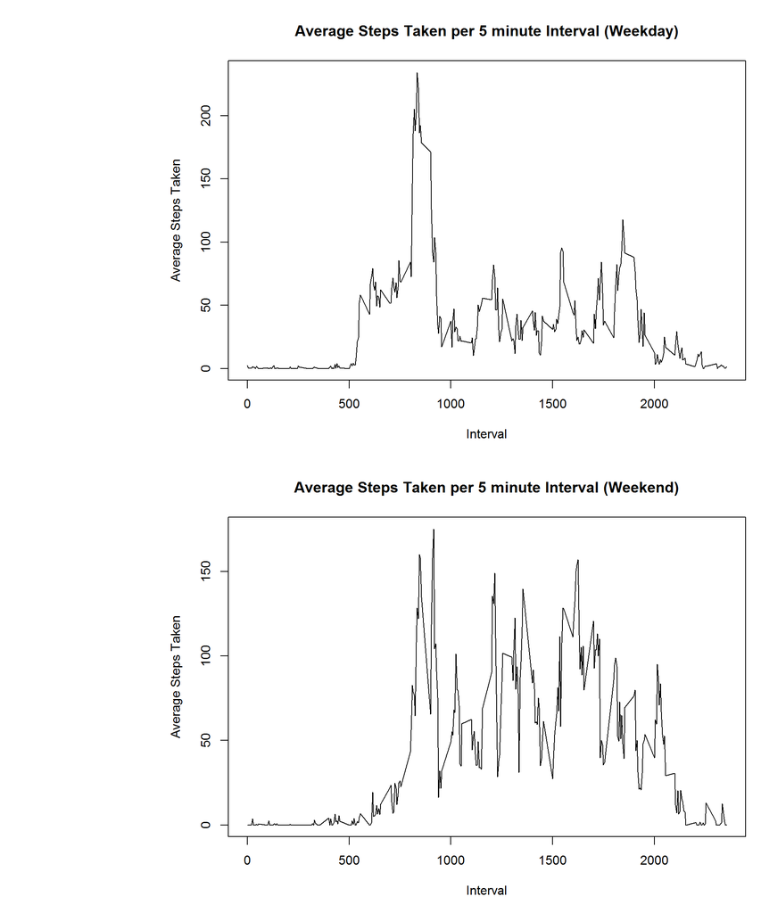

```r
processedweekday<-ddply(rawdata,.(weekday, interval),summarise,steps=mean(steps,na.rm=TRUE))
par(mar=c(5,15,4,1))
par( mfrow = c( 2, 1 ) )
with(subset(processedweekday,weekday=="weekday"),plot(interval, steps, type="l", xlab="Interval",ylab="Average Steps Taken", main="Average Steps Taken per 5 minute Interval (Weekday)"))
with(subset(processedweekday,weekday=="weekend"),plot(interval, steps, type="l", xlab="Interval",ylab="Average Steps Taken", main="Average Steps Taken per 5 minute Interval (Weekend)"))
```